# 2장. 분류 분석(1)

### 1절. 로지스틱 회귀분석

$$logit(p) =log(odds) =log(\frac{P(y)}{1-P(y)}) = \beta_0 + \beta_1 x_1
+\cdots+\beta_k x_k \\
=> P(y)=\frac{1}{1+exp[-(\beta_0 + \beta_1 x_1 +\cdots+\beta_k
x_k)]}\\$$

#### 1. R을 이용한 이항 로지스틱 회귀분석

- glm(formula, data, family=‘binomial’)
  - family : 분석에 따른 link function 선택 (binomial : 이항, gaussian : 가우시안, Gamma : 감마, poisson : 포아송)
- predict(model, newdata, type,….)
  - type : 예측 결과의 유형 (link : log-odds 값, class : 범주형 값, response : 0~1 확률값)

```r
credit <- read.csv('german_credit.csv')
head(credit)
```

```
##   Creditability Account.Balance Duration.of.Credit..month.
## 1             1               1                         18
## 2             1               1                          9
## 3             1               2                         12
## 4             1               1                         12
## 5             1               1                         12
## 6             1               1                         10
##   Payment.Status.of.Previous.Credit Purpose Credit.Amount Value.Savings.Stocks
## 1                                 4       2          1049                    1
## 2                                 4       0          2799                    1
## 3                                 2       9           841                    2
## 4                                 4       0          2122                    1
## 5                                 4       0          2171                    1
## 6                                 4       0          2241                    1
##   Length.of.current.employment Instalment.per.cent Sex...Marital.Status
```

[output cut: 27 more lines]

```r
credit$Creditability <- as.factor(credit$Creditability)
str(credit)
```

```
## 'data.frame':    1000 obs. of  21 variables:
##  $ Creditability                    : Factor w/ 2 levels "0","1": 2 2 2 2 2 2 2 2 2 2 ...
##  $ Account.Balance                  : int  1 1 2 1 1 1 1 1 4 2 ...
##  $ Duration.of.Credit..month.       : int  18 9 12 12 12 10 8 6 18 24 ...
##  $ Payment.Status.of.Previous.Credit: int  4 4 2 4 4 4 4 4 4 2 ...
##  $ Purpose                          : int  2 0 9 0 0 0 0 0 3 3 ...
##  $ Credit.Amount                    : int  1049 2799 841 2122 2171 2241 3398 1361 1098 3758 ...
##  $ Value.Savings.Stocks             : int  1 1 2 1 1 1 1 1 1 3 ...
##  $ Length.of.current.employment     : int  2 3 4 3 3 2 4 2 1 1 ...
##  $ Instalment.per.cent              : int  4 2 2 3 4 1 1 2 4 1 ...
##  $ Sex...Marital.Status             : int  2 3 2 3 3 3 3 3 2 2 ...
##  $ Guarantors                       : int  1 1 1 1 1 1 1 1 1 1 ...
##  $ Duration.in.Current.address      : int  4 2 4 2 4 3 4 4 4 4 ...
##  $ Most.valuable.available.asset    : int  2 1 1 1 2 1 1 1 3 4 ...
##  $ Age..years.                      : int  21 36 23 39 38 48 39 40 65 23 ...
##  $ Concurrent.Credits               : int  3 3 3 3 1 3 3 3 3 3 ...
##  $ Type.of.apartment                : int  1 1 1 1 2 1 2 2 2 1 ...
##  $ No.of.Credits.at.this.Bank       : int  1 2 1 2 2 2 2 1 2 1 ...
##  $ Occupation                       : int  3 3 2 2 2 2 2 2 1 1 ...
##  $ No.of.dependents                 : int  1 2 1 2 1 2 1 2 1 1 ...
##  $ Telephone                        : int  1 1 1 1 1 1 1 1 1 1 ...
##  $ Foreign.Worker                   : int  1 1 1 2 2 2 2 2 1 1 ...
```

```r
set.seed(1)
idx <- sample(1:nrow(credit),nrow(credit)*0.7,replace=F)
train <- credit[idx,]
test <- credit[-idx,]

logistic <- glm(Creditability~.,
               data = train,
               family = 'binomial')
summary(logistic)
```

```
##
## Call:
## glm(formula = Creditability ~ ., family = "binomial", data = train)
##
## Coefficients:
##                                     Estimate Std. Error z value Pr(>|z|)
## (Intercept)                       -3.998e+00  1.188e+00  -3.364 0.000767 ***
## Account.Balance                    5.809e-01  8.651e-02   6.714 1.89e-11 ***
## Duration.of.Credit..month.        -3.220e-02  1.070e-02  -3.008 0.002626 **
## Payment.Status.of.Previous.Credit  4.228e-01  1.026e-01   4.120 3.79e-05 ***
## Purpose                            6.230e-02  3.695e-02   1.686 0.091785 .
## Credit.Amount                     -1.143e-04  4.932e-05  -2.317 0.020510 *
## Value.Savings.Stocks               2.796e-01  7.200e-02   3.883 0.000103 ***
## Length.of.current.employment       7.883e-02  8.572e-02   0.920 0.357722
## Instalment.per.cent               -3.966e-01  1.015e-01  -3.905 9.41e-05 ***
## Sex...Marital.Status               2.084e-01  1.414e-01   1.474 0.140545
## Guarantors                         1.241e-01  2.115e-01   0.587 0.557360
## Duration.in.Current.address        2.527e-02  9.685e-02   0.261 0.794152
## Most.valuable.available.asset     -1.982e-01  1.138e-01  -1.742 0.081563 .
## Age..years.                        1.952e-02  1.016e-02   1.921 0.054711 .
## Concurrent.Credits                 1.532e-01  1.368e-01   1.120 0.262873
## Type.of.apartment                  3.800e-01  2.101e-01   1.809 0.070501 .
## No.of.Credits.at.this.Bank        -3.134e-01  1.874e-01  -1.672 0.094458 .
## Occupation                         2.139e-01  1.657e-01   1.291 0.196815
## No.of.dependents                  -2.902e-02  2.893e-01  -0.100 0.920102
## Telephone                          1.914e-01  2.257e-01   0.848 0.396503
## Foreign.Worker                     1.151e+00  6.404e-01   1.797 0.072340 .
## ---
## Signif. codes:  0 '***' 0.001 '**' 0.01 '*' 0.05 '.' 0.1 ' ' 1
##
## (Dispersion parameter for binomial family taken to be 1)
##
##     Null deviance: 865.13  on 699  degrees of freedom
## Residual deviance: 652.97  on 679  degrees of freedom
## AIC: 694.97
##
## Number of Fisher Scoring iterations: 5
```

=> 회귀계수의 p-value가 0.05보다 높게 나타나는 변수가 많으므로 단계적 선택법 이용

```r
# step 함수를 이용한 로지스틱
step.logistic <- step(glm(Creditability~1, data = train, family = 'binomial'),
                      scope = list(lower=~1, upper=~Account.Balance+Duration.of.Credit..month.+Payment.Status.of.Previous.Credit+Purpose+Credit.Amount+Value.Savings.Stocks+Length.of.current.employment+Instalment.per.cent+Sex...Marital.Status+Guarantors+Duration.in.Current.address+Most.valuable.available.asset+Age..years.+Concurrent.Credits+Type.of.apartment+No.of.Credits.at.this.Bank+Occupation+No.of.dependents+Telephone+Foreign.Worker),
                      direction = 'both')
```

```
## Start:  AIC=867.13
## Creditability ~ 1
##
##                                     Df Deviance    AIC
## + Account.Balance                    1   771.18 775.18
## + Payment.Status.of.Previous.Credit  1   821.32 825.32
## + Duration.of.Credit..month.         1   823.19 827.19
## + Value.Savings.Stocks               1   832.27 836.27
## + Credit.Amount                      1   847.56 851.56
## + Age..years.                        1   851.40 855.40
## + Most.valuable.available.asset      1   852.22 856.22
## + Length.of.current.employment       1   857.35 861.35
## + Instalment.per.cent                1   859.24 863.24
## + Foreign.Worker                     1   859.91 863.91
## + Sex...Marital.Status               1   860.89 864.89
## + Concurrent.Credits                 1   861.51 865.51
## <none>                                   865.13 867.13
## + Type.of.apartment                  1   863.41 867.41
## + Telephone                          1   863.89 867.89
## + No.of.Credits.at.this.Bank         1   864.27 868.27
## + No.of.dependents                   1   864.45 868.45
## + Occupation                         1   864.62 868.62
## + Guarantors                         1   865.10 869.10
## + Purpose                            1   865.13 869.13
## + Duration.in.Current.address        1   865.13 869.13
##
## Step:  AIC=775.18
## Creditability ~ Account.Balance
##
##                                     Df Deviance    AIC
## + Duration.of.Credit..month.         1   730.59 736.59
## + Payment.Status.of.Previous.Credit  1   745.17 751.17
## + Credit.Amount                      1   752.61 758.61
## + Most.valuable.available.asset      1   758.17 764.17
## + Value.Savings.Stocks               1   759.12 765.12
## + Age..years.                        1   762.86 768.86
## + Foreign.Worker                     1   763.08 769.08
## + Instalment.per.cent                1   763.87 769.87
## + Length.of.current.employment       1   767.46 773.46
## + Sex...Marital.Status               1   768.09 774.09
```

[output cut: 304 more lines]

```
## - Purpose                            1   664.47 688.47
## + Telephone                          1   660.51 688.51
## - No.of.Credits.at.this.Bank         1   664.63 688.63
## + Guarantors                         1   660.76 688.76
## - Foreign.Worker                     1   664.83 688.83
## - Sex...Marital.Status               1   665.10 689.10
## + Duration.in.Current.address        1   661.14 689.14
## + No.of.dependents                   1   661.16 689.16
## - Credit.Amount                      1   666.95 690.95
## - Age..years.                        1   670.07 694.07
## - Duration.of.Credit..month.         1   671.85 695.85
## - Instalment.per.cent                1   676.21 700.21
## - Value.Savings.Stocks               1   677.72 701.72
## - Payment.Status.of.Previous.Credit  1   683.84 707.84
## - Account.Balance                    1   712.46 736.46
```

```r
summary(step.logistic)
```

```
##
## Call:
## glm(formula = Creditability ~ Account.Balance + Duration.of.Credit..month. +
##     Payment.Status.of.Previous.Credit + Value.Savings.Stocks +
##     Instalment.per.cent + Age..years. + Credit.Amount + Sex...Marital.Status +
##     Foreign.Worker + No.of.Credits.at.this.Bank + Purpose + Occupation,
##     family = "binomial", data = train)
##
## Coefficients:
##                                     Estimate Std. Error z value Pr(>|z|)
## (Intercept)                       -3.074e+00  9.855e-01  -3.119 0.001813 **
## Account.Balance                    5.819e-01  8.524e-02   6.826 8.73e-12 ***
## Duration.of.Credit..month.        -3.356e-02  1.041e-02  -3.224 0.001266 **
## Payment.Status.of.Previous.Credit  4.621e-01  1.008e-01   4.583 4.58e-06 ***
## Value.Savings.Stocks               2.738e-01  7.014e-02   3.904 9.47e-05 ***
## Instalment.per.cent               -3.802e-01  1.004e-01  -3.787 0.000153 ***
## Age..years.                        2.627e-02  9.008e-03   2.917 0.003536 **
## Credit.Amount                     -1.155e-04  4.801e-05  -2.406 0.016138 *
## Sex...Marital.Status               2.679e-01  1.355e-01   1.977 0.048045 *
## Foreign.Worker                     1.105e+00  6.245e-01   1.770 0.076676 .
## No.of.Credits.at.this.Bank        -3.363e-01  1.810e-01  -1.858 0.063171 .
## Purpose                            6.554e-02  3.650e-02   1.796 0.072553 .
## Occupation                         2.179e-01  1.517e-01   1.436 0.150887
## ---
## Signif. codes:  0 '***' 0.001 '**' 0.01 '*' 0.05 '.' 0.1 ' ' 1
##
## (Dispersion parameter for binomial family taken to be 1)
##
##     Null deviance: 865.13  on 699  degrees of freedom
## Residual deviance: 661.16  on 687  degrees of freedom
## AIC: 687.16
##
## Number of Fisher Scoring iterations: 5
```

```r
pred <- predict(step.logistic, test[,-1],type = 'response')
pred1 <- as.data.frame(pred)
pred1$grade <- ifelse(pred1$pred<0.5,0,1)

library(caret)
confusionMatrix(data = as.factor(pred1$grade), reference = test[,1], positive = '1')
```

```
## Confusion Matrix and Statistics
##
##           Reference
## Prediction   0   1
##          0  37  33
##          1  47 183
##
##                Accuracy : 0.7333
##                  95% CI : (0.6795, 0.7825)
##     No Information Rate : 0.72
##     P-Value [Acc > NIR] : 0.3291
##
##                   Kappa : 0.3031
##
##  Mcnemar's Test P-Value : 0.1461
##
##             Sensitivity : 0.8472
##             Specificity : 0.4405
##          Pos Pred Value : 0.7957
##          Neg Pred Value : 0.5286
##              Prevalence : 0.7200
##          Detection Rate : 0.6100
##    Detection Prevalence : 0.7667
##       Balanced Accuracy : 0.6438
##
##        'Positive' Class : 1
##
```

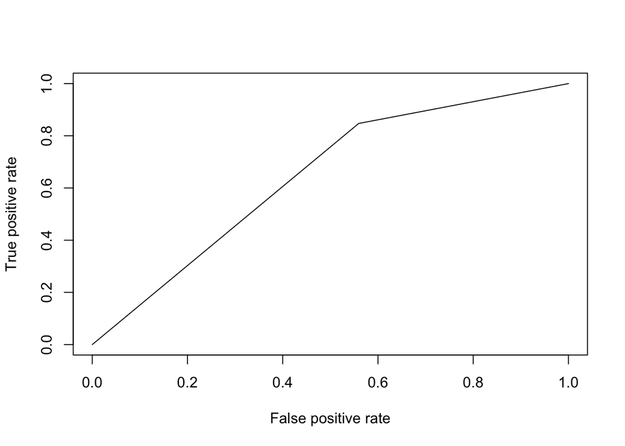

```r
# ROC
library(ROCR)
pred.logistic.roc <- prediction(as.numeric(pred1$grade),as.numeric(test[,1]))
plot(performance(pred.logistic.roc, 'tpr','fpr'))
```

```r
performance(pred.logistic.roc,'auc')@y.values
```

```
## [[1]]
## [1] 0.6438492
```

#### 2. R을 이용한 다항 로지스틱 회귀분석(nnet 패키지)

- multinom(formula, data)

```r
data(iris)

set.seed(1)
idx <- sample(1:nrow(iris),nrow(iris)*0.7,replace=F)
train.iris <- iris[idx,]
test.iris <- iris[-idx,]

library(nnet)
mul.iris <- multinom(Species~., train.iris)
pred.iris <- predict(mul.iris, test.iris[,-5])

confusionMatrix(pred.iris,test.iris[,5])
```

```
## Confusion Matrix and Statistics
##
##             Reference
## Prediction   setosa versicolor virginica
##   setosa         15          0         0
##   versicolor      0         17         2
##   virginica       0          0        11
##
## Overall Statistics
##
##                Accuracy : 0.9556
##                  95% CI : (0.8485, 0.9946)
##     No Information Rate : 0.3778
##     P-Value [Acc > NIR] : 2.61e-16
##
##                   Kappa : 0.9325
##
##  Mcnemar's Test P-Value : NA
##
## Statistics by Class:
##
##                      Class: setosa Class: versicolor Class: virginica
## Sensitivity                 1.0000            1.0000           0.8462
## Specificity                 1.0000            0.9286           1.0000
## Pos Pred Value              1.0000            0.8947           1.0000
## Neg Pred Value              1.0000            1.0000           0.9412
## Prevalence                  0.3333            0.3778           0.2889
## Detection Rate              0.3333            0.3778           0.2444
## Detection Prevalence        0.3333            0.4222           0.2444
## Balanced Accuracy           1.0000            0.9643           0.9231
```

### 2절. 의사결정나무

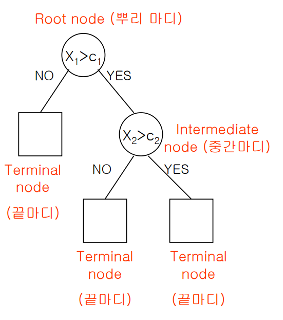

#### 1. 의사결정나무의 분석 과정

의사결정나무의 형성과정 - 성장, 가지치기, 타당성 평가, 해석 및 예측

- 성장

  적절한 최적의 분리 규칙(splitting rule)을 통해 성장, 정지규칙(stopping rule)을 통해 중단

  이산형 종속변수 - 카이제곱 통계량 p-value, 지니 지수, 엔트로피 지수  
  연속형 종속변수 - 분산분석에서 F 통계량, 분산의 감소량
- 가지치기

  마디에 속하는 자료가 일정 수(일반적으로 5) 이하 일 때 분할 정지하고 비용-복잡도 가지치기

  ※ 모형의 복잡도 = 나무의 크기
- 타당성 평가 단계

  이익도표, 위험도표, 시험자료를 이용하여 의사결정 나무를 평가
- 해석 및 예측 단계

#### 2. 의사결정나무 알고리즘

- CART(Classification and Regression Tree) : 범주형 -> 지니지수, 연속형 -> 분산
- C4.5 와 C5.0 : 다지분리 가능, 범주형 -> 엔트로피지수
- CHAID(Chi-squared Automatic Interaction Detection) : 범주형 변수 -> 카이제곱 통계량

#### 3. R을 이용한 의사결정나무 분석 (rpart 패키지)

- **rpart(formual, data, method, control=rpart.control(),…)**

  CART 방법
  - method : 의사결정나무 tree 종류 선정(‘anova’,‘poisson’,‘class’,‘exp’)
  - control : 의사결정나무를 만들 때 사용할 option 설정

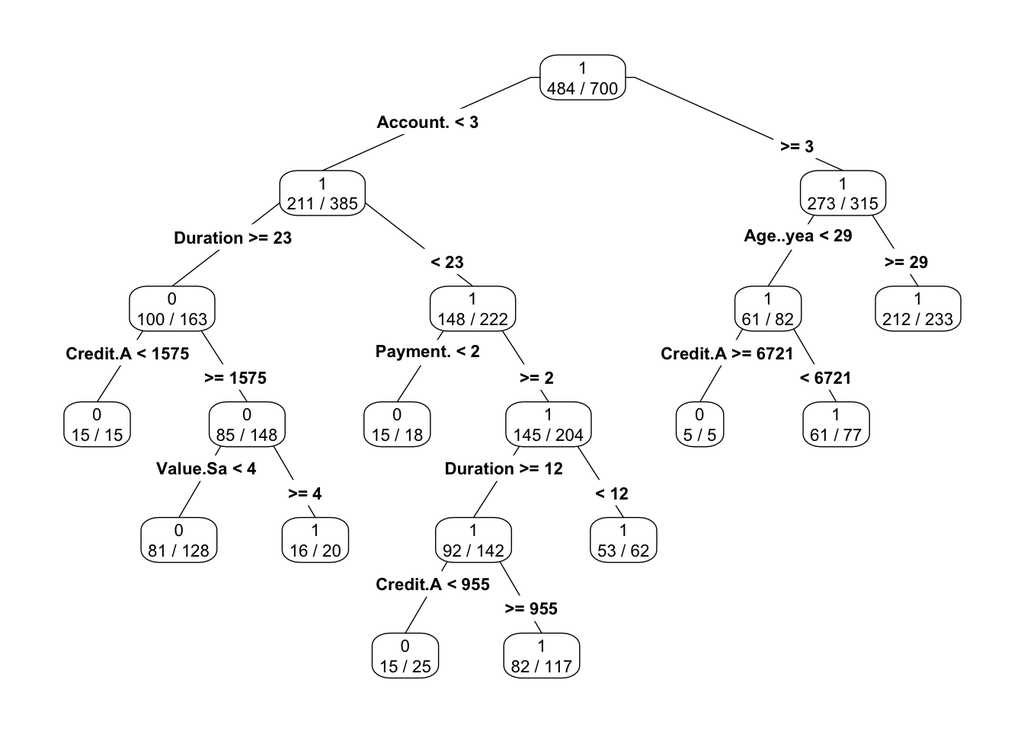

```r
library(rpart)
library(rpart.plot)
dt.model <- rpart(Creditability~.,
                  method = 'class',
                  data = train,
                  control = rpart.control(maxdepth = 5,
                                          minsplit = 15))
prp(dt.model, type = 4, extra = 2)
```

```r
dt.model$cptable
```

```
##           CP nsplit rel error    xerror       xstd
## 1 0.08564815      0 1.0000000 1.0000000 0.05657789
## 2 0.05555556      2 0.8287037 0.8935185 0.05473686
## 3 0.02777778      3 0.7731481 0.8796296 0.05447022
## 4 0.01157407      5 0.7175926 0.8379630 0.05363153
## 5 0.01000000      9 0.6712963 0.8333333 0.05353467
```

- cptable
  - nsplit : 분할 횟수
  - xerror, std : 해당 CP에서 cross validation했을 때 오류율, 편차

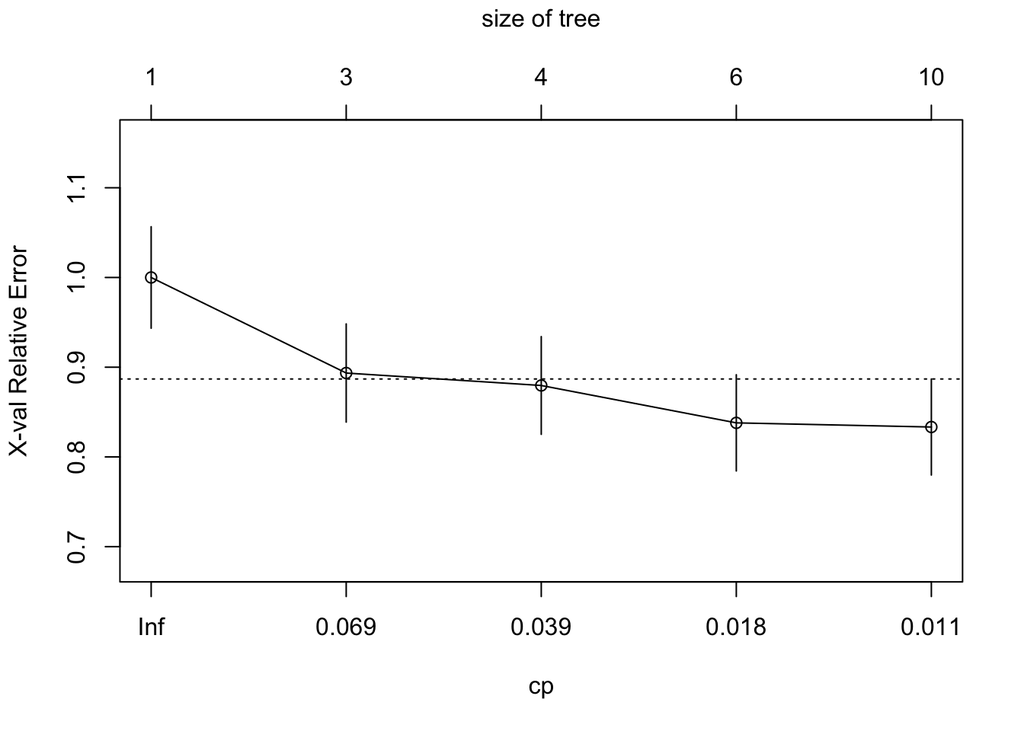

```r
# 최적 나무 선정
opt <- which.min(dt.model$cptable[,'xerror'])
cp <- dt.model$cptable[opt,"CP"]
prune.c <- prune(dt.model,cp=cp)
plotcp(dt.model)
```

- plotcp

  => xerror가 가장 낮을 때, 결과에 따라 교차타당성오차를 최소로 하는 트리를 형성  
  (나무의 크기가 10일 때 최적의 나무)

```r
# 오분류표
library(caret)
pred.dt <- predict(dt.model, test[,-1],type = 'class')
confusionMatrix(data = pred.dt, reference = test[,1],positive = '1')
```

```
## Confusion Matrix and Statistics
##
##           Reference
## Prediction   0   1
##          0  43  37
##          1  41 179
##
##                Accuracy : 0.74
##                  95% CI : (0.6865, 0.7887)
##     No Information Rate : 0.72
##     P-Value [Acc > NIR] : 0.2412
##
##                   Kappa : 0.3456
##
##  Mcnemar's Test P-Value : 0.7341
##
##             Sensitivity : 0.8287
##             Specificity : 0.5119
##          Pos Pred Value : 0.8136
##          Neg Pred Value : 0.5375
##              Prevalence : 0.7200
##          Detection Rate : 0.5967
##    Detection Prevalence : 0.7333
##       Balanced Accuracy : 0.6703
##
##        'Positive' Class : 1
##
```

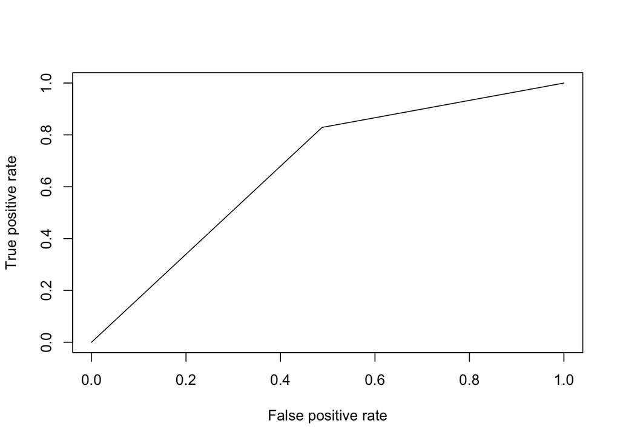

```r
# ROC 그래프
library(ROCR)
pred.dt.roc <- prediction(as.numeric(pred.dt),as.numeric(test[,1]))
plot(performance(pred.dt.roc,'tpr','fpr'))
```

```r
performance(pred.dt.roc,'auc')@y.values # AUC
```

```
## [[1]]
## [1] 0.6703042
```

#### 예제 - iris

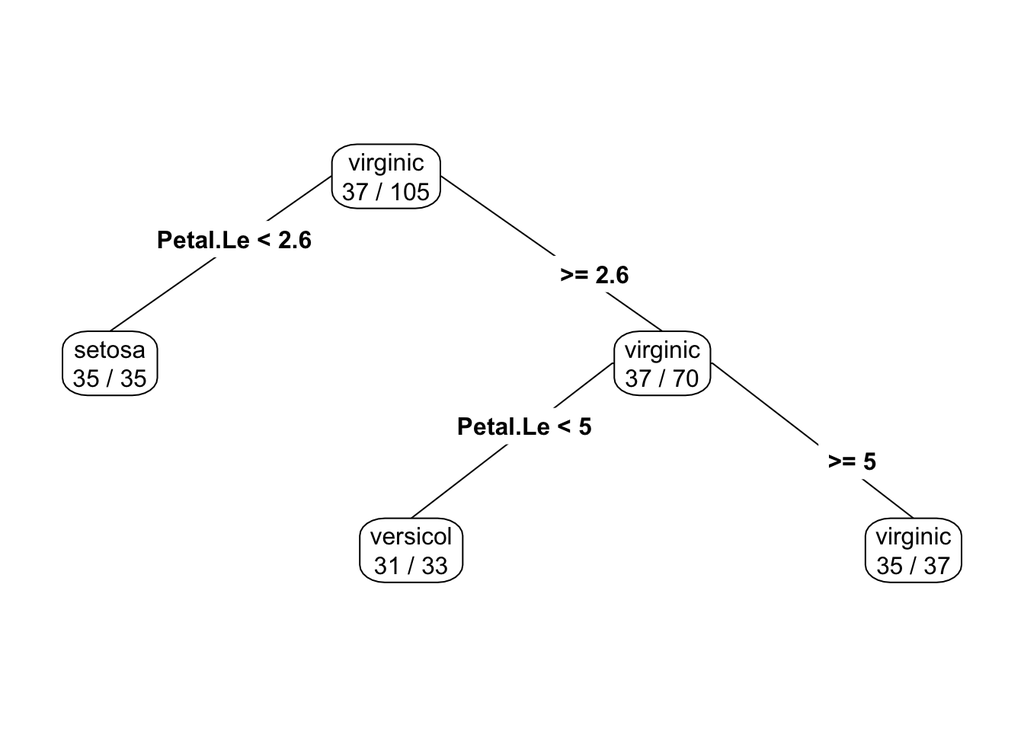

```r
library(rpart)
library(rpart.plot)

dt.model2 <- rpart(Species~., data = train.iris)
prp(dt.model2, type = 4, extra = 2)
```

```r
pred.dt2 <- predict(dt.model2, test.iris[,-5],type = 'class')
confusionMatrix(data = pred.dt2, reference = test.iris[,5])
```

```
## Confusion Matrix and Statistics
##
##             Reference
## Prediction   setosa versicolor virginica
##   setosa         15          0         0
##   versicolor      0         17         4
##   virginica       0          0         9
##
## Overall Statistics
##
##                Accuracy : 0.9111
##                  95% CI : (0.7878, 0.9752)
##     No Information Rate : 0.3778
##     P-Value [Acc > NIR] : 1.099e-13
##
##                   Kappa : 0.8643
##
##  Mcnemar's Test P-Value : NA
##
## Statistics by Class:
##
##                      Class: setosa Class: versicolor Class: virginica
## Sensitivity                 1.0000            1.0000           0.6923
## Specificity                 1.0000            0.8571           1.0000
## Pos Pred Value              1.0000            0.8095           1.0000
## Neg Pred Value              1.0000            1.0000           0.8889
## Prevalence                  0.3333            0.3778           0.2889
## Detection Rate              0.3333            0.3778           0.2000
## Detection Prevalence        0.3333            0.4667           0.2000
## Balanced Accuracy           1.0000            0.9286           0.8462
```

### 3절. 앙상블(ensemble) 기법

#### 1. 배깅(Bagging) (ipred 패키지)

: 여러 개의 붓스트랩 자료를 생성하고 각 붓스트랩 자료에 예측모형을 만든 후 결합하여 최종 예측모형을 만드는 방법

※ 붓스트랩은 단순랜덤 복원추출 방법을 활용하여 동일한 크기의 표본을 여러개 생성  
=> 샘플에 한 번도 선택되지 않는 원데이터(OOB)는 전체 샘플의 약 36.8%

- bagging(formula, data, mfinal, control=,…)
  - mfinal : 반복 수 또는 사용할 트리의 수(default=100)
  - control : 의사결정나무를 만들 때 사용할 option을 설정

```r
#install.packages('ipred')
library(ipred)
bag <- bagging(Creditability~.,
               data = train,
               mfinal=15)

pred.bg <- predict(bag, test, type = 'class')

# 오분류표
library(caret)
confusionMatrix(data = pred.bg, reference = test$Creditability,
                positive = '1')
```

```
## Confusion Matrix and Statistics
##
##           Reference
## Prediction   0   1
##          0  40  36
##          1  44 180
##
##                Accuracy : 0.7333
##                  95% CI : (0.6795, 0.7825)
##     No Information Rate : 0.72
##     P-Value [Acc > NIR] : 0.3291
##
##                   Kappa : 0.3188
##
##  Mcnemar's Test P-Value : 0.4338
##
##             Sensitivity : 0.8333
##             Specificity : 0.4762
##          Pos Pred Value : 0.8036
##          Neg Pred Value : 0.5263
##              Prevalence : 0.7200
##          Detection Rate : 0.6000
##    Detection Prevalence : 0.7467
##       Balanced Accuracy : 0.6548
##
##        'Positive' Class : 1
##
```

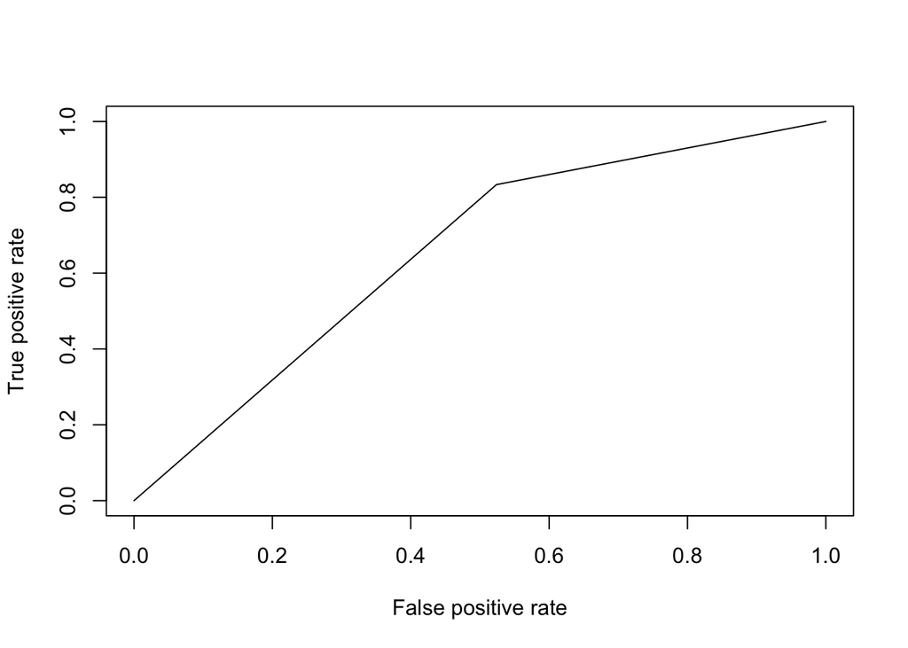

```r
# ROC 그래프와 AUC
library(ROCR)
pred.bg.roc <- prediction(as.numeric(pred.bg), as.numeric(test[,1]))
plot(performance(pred.bg.roc, 'tpr', 'fpr'))
```

```r
performance(pred.bg.roc,'auc')@y.values
```

```
## [[1]]
## [1] 0.6547619
```

#### 2. 부스팅(Boosting) (adabag 패키지)

: 예측력이 약한 모형들을 결합하여 강한 예측모형을 만드는 방법

- boosting(formula, data, boos=T/F, mfinal, control =,…)

#### 3. 랜덤포레스트(Random Forest) (randomForest 패키지)

: 약한 학습기들을 생성한 후 이를 선형 결합하여 최종학습기를 만드는 방법

해석이 어렵지만 예측력이 매우 높음.

- randomForest(formula, data, ntree, mtry,…)
  - ntree : 사용할 트리의 수
  - mtry : 각 분할에서 랜덤으로 뽑힌 변수의 개수(보통, 분류 -> sqrt(p), 회귀-> p/3 )

```r
library(randomForest)
set.seed(1)
rf.model <- randomForest(Creditability ~.,
                         data = train,
                         ntree=50,
                         mtry=sqrt(20),
                         importance=T) # 변수중요도 확인
rf.model
```

```
##
## Call:
##  randomForest(formula = Creditability ~ ., data = train, ntree = 50,      mtry = sqrt(20), importance = T)
##                Type of random forest: classification
##                      Number of trees: 50
## No. of variables tried at each split: 4
##
##         OOB estimate of  error rate: 24.14%
## Confusion matrix:
##     0   1 class.error
## 0 103 113   0.5231481
## 1  56 428   0.1157025
```

```r
rf.model$importance
```

```
##                                               0             1
## Account.Balance                    0.0743487103  0.0341338606
## Duration.of.Credit..month.         0.0158475118  0.0254233657
## Payment.Status.of.Previous.Credit  0.0178120006  0.0080299362
## Purpose                           -0.0047307755  0.0072924639
## Credit.Amount                      0.0096537639  0.0114541265
## Value.Savings.Stocks               0.0171954998  0.0007681715
## Length.of.current.employment       0.0063330585  0.0080435541
## Instalment.per.cent               -0.0038315917  0.0039520403
## Sex...Marital.Status              -0.0012064881  0.0021457800
## Guarantors                        -0.0012033796  0.0038276230
## Duration.in.Current.address       -0.0035099607  0.0015259864
## Most.valuable.available.asset     -0.0026991085  0.0065814979
## Age..years.                        0.0070681311  0.0078259309
## Concurrent.Credits                -0.0056280141  0.0007885196
## Type.of.apartment                 -0.0001324225  0.0016773763
## No.of.Credits.at.this.Bank        -0.0022278838  0.0015075870
## Occupation                         0.0086958478  0.0035540868
## No.of.dependents                   0.0007047675  0.0002744445
## Telephone                          0.0029329235 -0.0008941775
## Foreign.Worker                     0.0015373062  0.0002207980
##                                   MeanDecreaseAccuracy MeanDecreaseGini
## Account.Balance                           4.668459e-02        33.568885
## Duration.of.Credit..month.                2.233619e-02        32.531138
## Payment.Status.of.Previous.Credit         1.095840e-02        16.972764
## Purpose                                   3.544585e-03        16.472215
## Credit.Amount                             1.093505e-02        37.058804
## Value.Savings.Stocks                      6.029774e-03        16.320448
## Length.of.current.employment              7.402413e-03        13.787017
## Instalment.per.cent                       1.494328e-03        13.180867
## Sex...Marital.Status                      1.159122e-03        10.750513
## Guarantors                                2.206379e-03         5.882478
## Duration.in.Current.address               1.381405e-05        10.979850
## Most.valuable.available.asset             3.589263e-03        13.747475
## Age..years.                               7.535566e-03        30.417664
## Concurrent.Credits                       -1.130074e-03         5.765428
## Type.of.apartment                         1.178479e-03         7.954627
## No.of.Credits.at.this.Bank                3.595018e-04         6.749694
## Occupation                                5.054860e-03         9.912096
## No.of.dependents                          4.591430e-04         3.890516
## Telephone                                 3.639672e-04         5.949816
## Foreign.Worker                            6.347309e-04         1.641676
```

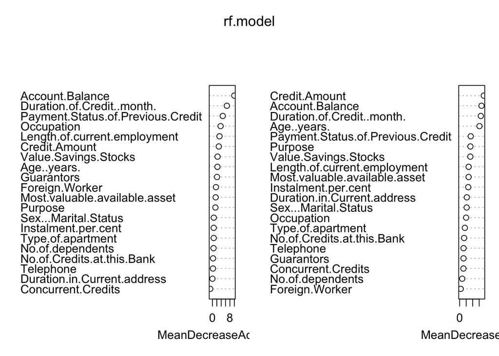

```r
varImpPlot(rf.model)
```

```r
pred.rf <- predict(rf.model, test[,-1],type = 'class')

# 오분류표
library(caret)
confusionMatrix(data = pred.rf , reference = test[,1], positive = '1')
```

```
## Confusion Matrix and Statistics
##
##           Reference
## Prediction   0   1
##          0  38  31
##          1  46 185
##
##                Accuracy : 0.7433
##                  95% CI : (0.69, 0.7918)
##     No Information Rate : 0.72
##     P-Value [Acc > NIR] : 0.2024
##
##                   Kappa : 0.3267
##
##  Mcnemar's Test P-Value : 0.1106
##
##             Sensitivity : 0.8565
##             Specificity : 0.4524
##          Pos Pred Value : 0.8009
##          Neg Pred Value : 0.5507
##              Prevalence : 0.7200
##          Detection Rate : 0.6167
##    Detection Prevalence : 0.7700
##       Balanced Accuracy : 0.6544
##
##        'Positive' Class : 1
##
```

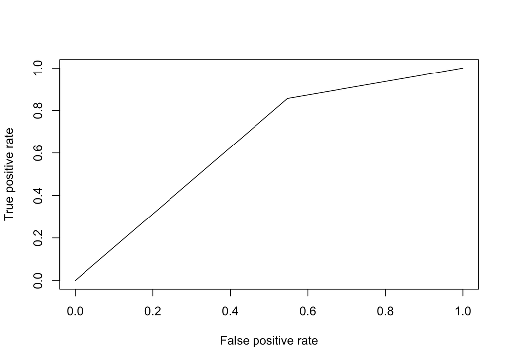

```r
# ROC 그래프와 AUC
library(ROCR)
pred.rf.roc <- prediction(as.numeric(pred.rf),as.numeric(test[,1]))
plot(performance(pred.rf.roc,'tpr','fpr'))
```

```r
performance(pred.rf.roc,'auc')@y.values
```

```
## [[1]]
## [1] 0.6544312
```

#### 예제 - iris

```r
library(randomForest)
set.seed(1)
rf.model2 <- randomForest(Species ~.,
                          data = train.iris,
                          ntree=50,
                          mtry=sqrt(4),
                          importance=T)
pred.rf2 <- predict(rf.model2,test.iris[,-5],type = 'class')

library(caret)
confusionMatrix(data = pred.rf2, reference = test.iris[,5], positive = '1')
```

```
## Confusion Matrix and Statistics
##
##             Reference
## Prediction   setosa versicolor virginica
##   setosa         15          0         0
##   versicolor      0         17         2
##   virginica       0          0        11
##
## Overall Statistics
##
##                Accuracy : 0.9556
##                  95% CI : (0.8485, 0.9946)
##     No Information Rate : 0.3778
##     P-Value [Acc > NIR] : 2.61e-16
##
##                   Kappa : 0.9325
##
##  Mcnemar's Test P-Value : NA
##
## Statistics by Class:
##
##                      Class: setosa Class: versicolor Class: virginica
## Sensitivity                 1.0000            1.0000           0.8462
## Specificity                 1.0000            0.9286           1.0000
## Pos Pred Value              1.0000            0.8947           1.0000
## Neg Pred Value              1.0000            1.0000           0.9412
## Prevalence                  0.3333            0.3778           0.2889
## Detection Rate              0.3333            0.3778           0.2444
## Detection Prevalence        0.3333            0.4222           0.2444
## Balanced Accuracy           1.0000            0.9643           0.9231
```